# Exemple_PRA2

[figure not shown]

M2.893 · Anàlisi de textos

Màster Universitari de Ciència de Dades

Estudis d'Informàtica, Multimèdia i Telecomunicacions

# PRA 2: Deep Learning per a l'anàlisi de textos (Exemple)

En aquesta pràctica revisarem i aplicarem els coneixements apresos en el últims mòduls del curs. Treballarem els següents temes:

1. **Traducció automàtica(TA)**: amb 'custom embeddings' i amb 'embeddings preentrenats'.
2. **NER i NEL**: Entrenament de models de detecció d'entitats anomenades (NER), detecció i classificació. Detección de entitats anomenades basant-nos en Wikidata aplicada a NER.

També inclourem altres temes transversals treballats al llarg de l'assignatura.

# 0 Connexió amb 'Google Drive'

Aquesta secció realitza la connexió amb `drive` i estableix el directori arrel en el que s'emmagatzemem tots els recursos necessaris per a executar el notebook.

El 'path' de treball s'emmagatzema a la variable `my_path_pra2`.

**Estructura de directoris**

S'estableix el directori arrel segons la variable `my_path_pra2`. En aquest directori s'emmagatzemaran els arxius i directoris necessaris per a l'execució del notebook. L'estructura i continguts són els següents:

```
* directori `TA` on s'emmagatzemen les dades i recursos per a realitzar la traducció automàtica; conté:
  * glove.42B.300d.txt    # carregat per l'usuari.
  * nld.txt      # carregat per l'usuari.
  * directori `model` on s'emmagatzemen els *best model* de l'entrenament dels models de traducció automàtica:
    * model_ta_en_de-g.keras    # 'best model' generat per l'entrenament de TA amb 'embeddings' preentrenats
    * model_ta_en_de.keras      # 'best model' generat por l'entrenament de TA amb 'custom' embeddings.
* directori `NER` amb els arxius necessaris per a la pràctica NER:
    * Directori `output_ner`   on s'hi trobaran els *model-best* y *model-last* entrenats per aquest notebook.
    * config.cfg    # carregat per l'usuari.
    * test.txt      # carregat per l'usuari.
    * test.spacy    # Conversió de test.txt al format spacy
    * train.txt     # carregat per l'usuari.
    * train.spacy   # Conversió de train.txt al format spacy
    * valid.txt     # carregat per l'usuari.
    * valid.spacy   # Conversió de valid.txt al format spacy
```

**Execució d'aquest notebook en un entorno no `Colab`.**

Si no s'executa aquest notebook a Google Colab, substituir aquesta secció (*0. Connexió amb Google Drive*) per la corresponent a la configuració desitjada, tenint en compte que cal disposar d'una GPU amb, almenys, 15 GB de memòria RAM.

**Execució d'aquest notebook en un entorno `Colab`.**

Si s'executa aquest notebook a Colab, cal utilitzar almenys una GPU del tipus 'T4 GPU' o superior. Tenir en compte que si s'utilitza el servei gratuït de Colab, aquestes GPU no estan disponibles permanentment i, quan ho estan, només se'n pot disposar mentre duren les 'compute units' assignades a l'usuari o per límits de disponibilitat de GPUs de Google. Quan no hi ha disponibilitat, cal esperar a una nova assignació. Google no publica el mètode d'assignació o els [terminis de disposició](https://research.google.com/colaboratory/faq.html#usage-limits) de GPUs. Consulta a Colab (Opció de menú 'Runtime' >>>> 'View resources') la disponibilitat en cada moment de Compute Units i GPUs.

En tots els casos, aquest notebook pressuposa l'estructura de directoris de treball descrita.

```python
# Colab myDrive access
from google.colab import drive
drive.mount('/content/drive')
```

```python
import os

# Root directory

my_path_pra2 = "/content/drive/MyDrive/UOC/20251_Mineria_de_Textos/PRA2"

if os.path.exists(my_path_pra2):
    try:
        os.chdir(my_path_pra2)
        print(f"Root directory: '{os.getcwd()}'")
    except Exception as e:
        print(f"Error when changing root directory: '{my_path_pra2}'. Error: {e}")
else:
    print(f"Directory '{my_path_pra2}' doesn't exist")
```

```
Root directory: '/content/drive/MyDrive/UOC/20251_Mineria_de_Textos/PRA2'
```

# Imports

```python
#############################################
# SOLUCIÓ                                   #
#############################################

import keras
from keras import optimizers
from keras.utils import pad_sequences
from keras import layers
from keras.callbacks import ModelCheckpoint, EarlyStopping
from keras.models import Sequential, load_model
from keras.layers import Dense, LSTM, Embedding, RepeatVector

import matplotlib.pyplot as plt
import numpy as np
from numpy import array
import pandas as pd
from sklearn.model_selection import train_test_split
```

# 1 Traducció Automàtica (TA) (7 puntos)

En aquesta primera part de la pràctica es demana resoldre els exercicis usant la llibreria **KERAS**.

## 1.1 TA amb Custom Embeddings

L'objectiu d'aquest apartat és entrenar un model de traducció automàtica entre dos idiomes a partir de l'arxiu escollit, seguint els mateixos passos que el notebook de *Machine Translation*.

**Implementació:** Seguint els passos treballats en el notebook de traducció automàtica, implementar i entrenar un model de traducció automàtica, de l'**idioma origen** a l'**idioma destí**.

- En aquest notebook d'exemple s'utilitza com a dimensión de la capa d'embedding (*embedding_vec_length*) el valor de 200. Més endavant, es variarà aquesta dimensió i es revisaran els resultats.
- La longitud de seqüència es determinant en la duració del temps de procés i en el consum de memòria del processador durant l'entrenament. A Google Colab es pot cancel·lar el programa si es consumeix tota la memòria disponible. Provar amb diferents longituds, des de 4 (molt reduïda i, per tant, produirà una qualitat baixa de traducció), fins a longituds més grans (8, 12, 16).
- Finalment, es mostrarà com aplicar el model entrenat amb exemples de l'arxiu de dataset.

### 1.1.0 Hiperparàmetres

Notar que:

- En aquest exercici utilitzarem 'max_text_length' tant per a la seqüència d'entrada com de sortida.

```python
# Model hyperparameters

max_text_length = 8          # Maximum number of tokens allowed per input  and output sequence
embedding_vec_length = 200   # Dimensionality of the dense vector representing each token.
units = 512                  # LSTM Layer Units
epochs = 100                 # Training epochs
patience = 10                # early stopping patience
batch_size = 64              # Number of training examples per step
```

### 1.1.1 Preparació de dades

Primer prepararem les dades seleccionades (tingueu en compte que l'*idioma origen* ha de ser **anglès**), per a que es puguin llegir correctament i tinguin el format adequat per a la pràctica.

**a. Carreguem les dades des de la font seleccionada.**

*Sortides esperades:*

- Longitud del dataset.
- Almenys 3 files de dades que mostrin els textos de l'idioma origen i la respectiva traducció.

```python
#############################################
# SOLUCIÓ                                   #
#############################################

eng_dutch = pd.read_csv("TA/nld.txt",sep='\t', header=None, usecols=[0,1])

eng_dutch = array(eng_dutch)
print("Dataset length: ", len(eng_dutch))
eng_dutch[:3]
```

```
Dataset length:  73576
```

```
array([['Go.', 'Lopen!'],
       ['Go.', 'Vooruit.'],
       ['Hi.', 'Hoi.']], dtype=object)
```

**b. Preprocessar les dades, per a eliminar la puntuació i convertir a minúscula.**

*Sortida esperada:* Hauràs de mostrar el conjunt de dades normalitzat. Per exemple, la frase en l'idioma origen, "Hello, world!" es transformarà en l'idioma destí "Hola, món".

```python
#############################################
# SOLUCIÓ                                   #
#############################################


import string

#...

eng_dutch
```

```
array([['go', 'lopen'],
       ['go', 'vooruit'],
       ['hi', 'hoi'],
       ...,
       ['if you translate from your second language into your own native language rather than the other way around youre less likely to make mistakes',
        'als je vanuit je tweede taal naar je eigen moedertaal vertaalt in plaats van andersom maak je minder snel fouten'],
       ['the tatoeba project which can be found online at tatoebaorg is working on creating a large database of example sentences translated into many languages',
        'het tatoebaproject dat je online kan vinden op tatoebaorg werkt aan een grote gegevensbank met in vele talen vertaalde voorbeeldzinnen'],
       ['if someone who doesnt know your background says that you sound like a native speaker it means they probably noticed something about your speaking that made them realize you werent a native speaker in other words you dont really sound like a native speaker',
        'als iemand die je achtergrond niet kent zegt dat je klinkt als een moedertaalspreker betekent dat dat diegene waarschijnlijk iets in je spreken opgemerkt heeft dat hem deed realiseren dat je geen moedertaalspreker bent met andere woorden je klinkt niet echt als een moedertaalspreker']],
      dtype=object)
```

**c. Per a tenir una idea de la mida dels textos a analitzar, en funció de la quantitat de paraules, visualitzem les dades resultants amb un histograma.**

*Sortida esperada:* Dos histogramas que mostrin la quantitat de tokens dels textos del corpus, un per als vectors de l'idioma origen i l'altre per als de destí.

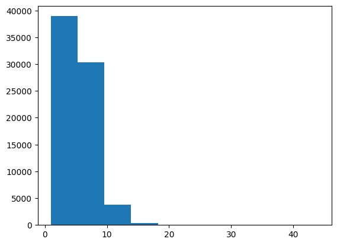

```python
#############################################
# SOLUCIÓ                                   #
#############################################

# Plot Source language

#...
```

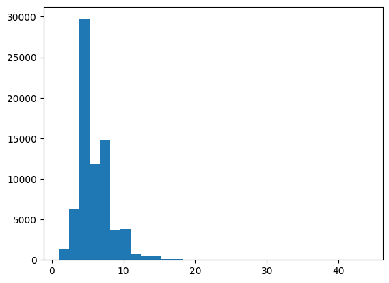

```python
#############################################
# SOLUCIÓ                                  #
#############################################

# Plot target language

#...
```

**d. Calculem el vocabulari tant el de l'idioma origen, com el de l'idioma destí, i imprimim el nombre de paraules**.

*Resultat esperat:*

- Es visualitzaran dos nombres, el de paraules del vocabulari de l'idioma origen i el de destí, després d'haver aplicat el preprocessament i la tokenització.
- Llista dels 10 primers tokens de cada idioma

```python
#############################################
# SOLUCIÓ                                   #
#############################################

# Hint: as vectorizer you can use layers.TectVectorization as it follows:
"""
def tokenization(sentences, length):
    vectorizer = layers.TextVectorization(
        max_tokens=None,
        output_mode='int',
        output_sequence_length=length  # This handles padding automatically!
    )
    vectorizer.adapt(sentences)
    return vectorizer

eng_tokenizer = tokenization(eng_dutch[:, 0], max_text_length)
eng_vocab = eng_tokenizer.get_vocabulary()
"""
# ...

print(f"English Vocab Size: {eng_vocab_size}")

# ...

print(f"Dutsch Vocab Size: {de_vocab_size}")

# Get lists of tokens

# ...
```

```
English Vocab Size: 10102
Dutsch Vocab Size: 14587

First 10 Tokens English:
Index 0: ''
Index 1: '[UNK]'
Index 2: 'i'
Index 3: 'tom'
Index 4: 'the'
Index 5: 'you'
Index 6: 'to'
Index 7: 'a'
Index 8: 'is'
Index 9: 'that'

First 10 Tokens Dutsch:
Index 0: ''
Index 1: '[UNK]'
Index 2: 'ik'
Index 3: 'tom'
Index 4: 'is'
Index 5: 'het'
Index 6: 'je'
Index 7: 'de'
Index 8: 'dat'
Index 9: 'een'
```

**e. Separem els conjunts d'entrenament per idioma i els codifiquem.**

En aquest pas, se separen les dades en dos conjunts: un per a entrenament (*train*) i l'altre per a prova (*test*), utilitzant una divisió del 80% per a entrenament i 20% per a prova.

*Sortida esperada:* tres primeres files del dataset d'entrenament *train*.

```python
#############################################
# SOLUCIÓ                                  #
#############################################

# ...

print(f"Train size: {len(train)}")
print(f"\nTest size: {len(test)}")
print(f"\nFirst 3 rows: \n{train[:3]}")
```

```
Train size: 58860

Test size: 14716

First 3 rows:
[['tom is very interested in biology'
  'tom is erg geïnteresseerd in biologie']
 ['do you think i should go alone'
  'denken jullie dat ik alleen moet gaan']
 ['we dont have time to debate' 'we hebben geen tijd om te discussiëren']]
```

**f. Definir i aplicar una funció per a codificar les seqüències**

En aquest pas, els dos conjunts de dades creats en el punt anterior, seran codificats usant **tokenització** i un procés de **padding** per a assegurar que totes les seqüències d'un mateix idioma tinguin la mateixa longitud.

**Important:** Per a executar aquest exemple, s'ha utilitzat l'accelerador de hardware *T4 GPU*, amb el paràmetre **longitud de seqüència** amb el valor de 8. No obstant això, si no és disposa d'aquest tipus de hardware, es pot reduir el valor, tot i que els resultats seran menys precisos.

*Sortida esperada:* Mida de cada arxiu i mostra de les tres primeres seqüències codificades de l'arxiu d'entrenament.

```python
#############################################
# SOLUCIÓ                                  #
#############################################


# Hint to encode sequences you can use:
"""
def encode_sequences(tokenizer, length, lines):
    # Vectorize the text. Returns a tensor of shape (batch_size, max_text_length) due to the definition of the tokenizer.
    seq = tokenizer(lines)
    seq = seq[:, :length]        # Note that padding is 'post'
    return seq
"""

#...

print(f"Train shapes: {trainX.shape}, {trainY.shape}")

print(f"Test shapes: {testX.shape}, {testY.shape}")

print(f"First 3 English Train rows: {trainX[:3]}")

print(f"First 3 Dutsch Train rows: {trainY[:3]}")
```

```
Train shapes: (58860, 8), (58860, 8)
Test shapes: (14716, 8), (14716, 8)
First 3 English Train rows: [[   3    8   48  445   11 1777    0    0]
 [  10    5   47    2  126   45  220    0]
 [  24   21   13   56    6 2838    0    0]]
First 3 Dutsch Train rows: [[   3    4   72  608   13 2158    0    0]
 [ 384   38    8    2  122   44   59    0]
 [  18   37   35   94   30   12 3030    0]]
```

### 1.1.2 Definició model encoder-decoder i entrenament

En aquest notebook d'exemple, es proporcionen dos subapartats per a l'entrenament del model:

- 1.1.2.1. Definició i entrenament del model, assumint una execució contínua, és a dir, hi ha disponiblitat de GPUs per a completar l'entrenament.
- 1.1.2.2. Es realitza l'entrenament, però es 'reinicia' el procés per una cancel·lació anticipada.

Per a la confecció de la PRA2 es pot adoptar aquest enfoc, en cas de que ocorrin interrupcions.

#### 1.1.2.1 Definir i entrenar

**a. Definim el model *encoder-decoder* basant-nos en el notebook vist a l'assignatura**, i l'instanciem amb una capa d'embedding per a les frases de la **llengua origen** i la dimensió de la última capa com la del vocabulario de la **llengua destí**.

**Important:** Per a la definició del model, considerar els següents paràmetres i valors referencials:

- Com a quantitat de **units** treballar, inicialment, amb el valor de 512. El nombre d'unitats o cel·les de memòria de cada capa LSTM defineix la dimensionalitat de l'espai intern en el que la LSTM processa i representa la informació al llarg del temps; és a dir, és la mida del vector de l'estat ocult *hidden state* i de l'estat de cel·la *cell state* que la LSTN manté per a capturar patrons i dependències de les seqüències d'entrada.

A major nombre de *units*, augmenta la capacitat del model per a modelar relacions complexes i dependències a llarg termini en el text, la qual cosa és clau per a la traducció automàtica, on el context pot comprendre vàries paraules o frases. No obstant això, un valor alt incrementa el nombre de paràmetres i, per tant, requerirà més memòria i temps de càlcul; a més, creix el risc de sobreajustament si les dades d'entrenament no són suficients.

- Longitud dels vectors d'embeddings *embedding_vec_length*: establir-lo en 200; aquest és un valor referencial que podría ser ajustat segons la mida del vocabulari, la complexitat de l'idioma i els recursos disponibles. Més endavant, *exercici 1.1.3* es demanar variar aquest valor.

**Resultat esperat:** s'haurà instanciat un modelo encoder-decoder. Aquest model està dissenyat per a processar i traduir textos de l'**idioma origen** a l'**idioma destí** utilitzant capes d'embedding i LSTM.

*Sortida esperada*: Utilitzar el mètode *mt_model.summary()* per a visualitzar l'estructura i configuració del model, incloent el nombre de paràmetres i la disposició de les capes.

```python
#############################################
# SOLUCIÓ                                  #
#############################################

# ...

print("Model built successfully")
mt_model.summary()
```

```
Model built successfully
```

```
Model: "sequential"
```

```
┏━━━━━━━━━━━━━━━━━━━━━━━━━━━━━━━━━┳━━━━━━━━━━━━━━━━━━━━━━━━┳━━━━━━━━━━━━━━━┓
┃ Layer (type)                    ┃ Output Shape           ┃       Param # ┃
┡━━━━━━━━━━━━━━━━━━━━━━━━━━━━━━━━━╇━━━━━━━━━━━━━━━━━━━━━━━━╇━━━━━━━━━━━━━━━┩
│ embedding (Embedding)           │ (None, 8, 200)         │     2,020,400 │
├─────────────────────────────────┼────────────────────────┼───────────────┤
│ lstm (LSTM)                     │ (None, 512)            │     1,460,224 │
├─────────────────────────────────┼────────────────────────┼───────────────┤
│ repeat_vector (RepeatVector)    │ (None, 8, 512)         │             0 │
├─────────────────────────────────┼────────────────────────┼───────────────┤
│ lstm_1 (LSTM)                   │ (None, 8, 512)         │     2,099,200 │
├─────────────────────────────────┼────────────────────────┼───────────────┤
│ dense (Dense)                   │ (None, 8, 14587)       │     7,483,131 │
└─────────────────────────────────┴────────────────────────┴───────────────┘
```

```
 Total params: 13,062,955 (49.83 MB)
```

```
 Trainable params: 13,062,955 (49.83 MB)
```

```
 Non-trainable params: 0 (0.00 B)
```

**b. Compilem el model**

**Resultat esperat:** el model compilat i llest per a ser entrenat. S'utilitzarà l'optimitzador *RMSprop* amb una tasa d'aprenentatge de *0.001* i la funció de pèrdua *sparse_categorical_crossentropy*.

*Sortida esperada*: Utilitzar el mètode mt_model.summary() per a visualitzar l'estructura i configuració del model, incloent el nombre de paràmetres i la disposició de les capes.

```python
#############################################
# SOLUCIÓ                                   #
#############################################

# ...

mt_model.summary()
```

```
Model: "sequential"
```

```
┏━━━━━━━━━━━━━━━━━━━━━━━━━━━━━━━━━┳━━━━━━━━━━━━━━━━━━━━━━━━┳━━━━━━━━━━━━━━━┓
┃ Layer (type)                    ┃ Output Shape           ┃       Param # ┃
┡━━━━━━━━━━━━━━━━━━━━━━━━━━━━━━━━━╇━━━━━━━━━━━━━━━━━━━━━━━━╇━━━━━━━━━━━━━━━┩
│ embedding (Embedding)           │ (None, 8, 200)         │     2,020,400 │
├─────────────────────────────────┼────────────────────────┼───────────────┤
│ lstm (LSTM)                     │ (None, 512)            │     1,460,224 │
├─────────────────────────────────┼────────────────────────┼───────────────┤
│ repeat_vector (RepeatVector)    │ (None, 8, 512)         │             0 │
├─────────────────────────────────┼────────────────────────┼───────────────┤
│ lstm_1 (LSTM)                   │ (None, 8, 512)         │     2,099,200 │
├─────────────────────────────────┼────────────────────────┼───────────────┤
│ dense (Dense)                   │ (None, 8, 14587)       │     7,483,131 │
└─────────────────────────────────┴────────────────────────┴───────────────┘
```

```
 Total params: 13,062,955 (49.83 MB)
```

```
 Trainable params: 13,062,955 (49.83 MB)
```

```
 Non-trainable params: 0 (0.00 B)
```

**c. Entrenem i guardem el model.**

**Important:** El model pot trigar hores si es disposa de CPU, molt menys amb GPU. Colab permet l'ús de GPU en general, si no se'n fa un ús intensiu i continuat. Per tant, habilitar només la GPU quan es necessiti per a entrenar i predir. Deshabilitar-la (i per tant reiniciar l'entorn) per a executar les cel·les no necessàries per a entrenar. L'apartat 1.1.2.2 explica com:

- Reiniciar l'entrenament a partir de l'última època emmagatzemada en un model intermedi ja entrenat.
- Carregar el model, ja entrenat per a següents sessions de treball, sense haver de realitzar de nou l'entrenament.

En cas de realitzar diferents variacions en els paràmetres de treball, poden emmagatzemar-se els models ja entrenats amb diferents noms per a la recuperació posterior (per exemple amb diferents longituds de seqüència, diferents unit, diferent batch size,...)

Amb la configuració indicada, però amb una longitud de seqüència de 12, també s'ha pogut dur a terme l'entrenament, però durant la predicció, el notebook va cancel·lar. Vam reiniciar, vam carregar el model des de l'últim 'callback' i la predicció es va realitzar sobre les 100 primeres frases.

- Per tant, per a provar si funciona, recomanem executar l'entrenament inicialment amb una sola 'època' i comprovar que funciona. Un cop comprovat que el procés està funcionant, incrementem el valor, per exemple a 50 o 100.
- Si, durant l'entrenament Colab no pot carregar el model en memòria, disminuir el valor de **longitud de paraula** a 4, d'aquesta manera, podrem completar el procés tot i que, probablement, els resultats no seran bons.

*Sortida Esperada*

- Path de la carpeta on s'ubicarà el best model
- Gràfica validation_loss / training_loss

```
736/736 ━━━━━━━━━━━━━━━━━━━━ 0s 81ms/step - accuracy: 0.3323 - loss: 5.1320
Epoch 1: val_loss improved from inf to 4.38204, saving model to TA/model/model_ta_en_de.keras
736/736 ━━━━━━━━━━━━━━━━━━━━ 85s 99ms/step - accuracy: 0.3323 - loss: 5.1312 - val_accuracy: 0.3524 - val_loss: 4.3820
736/736 ━━━━━━━━━━━━━━━━━━━━ 0s 80ms/step - accuracy: 0.3554 - loss: 4.2850
Epoch 2: val_loss improved from 4.38204 to 4.20755, saving model to TA/model/model_ta_en_de.keras
736/736 ━━━━━━━━━━━━━━━━━━━━ 66s 90ms/step - accuracy: 0.3554 - loss: 4.2850 - val_accuracy: 0.3670 - val_loss: 4.2076
736/736 ━━━━━━━━━━━━━━━━━━━━ 0s 80ms/step - accuracy: 0.3712 - loss: 4.1431
Epoch 3: val_loss improved from 4.20755 to 4.07722, saving model to TA/model/model_ta_en_de.keras
736/736 ━━━━━━━━━━━━━━━━━━━━ 66s 90ms/step - accuracy: 0.3712 - loss: 4.1431 - val_accuracy: 0.3906 - val_loss: 4.0772
736/736 ━━━━━━━━━━━━━━━━━━━━ 0s 80ms/step - accuracy: 0.3978 - loss: 3.9718
Epoch 4: val_loss improved from 4.07722 to 3.89621, saving model to TA/model/model_ta_en_de.keras
736/736 ━━━━━━━━━━━━━━━━━━━━ 66s 90ms/step - accuracy: 0.3978 - loss: 3.9717 - val_accuracy: 0.4126 - val_loss: 3.8962
736/736 ━━━━━━━━━━━━━━━━━━━━ 0s 84ms/step - accuracy: 0.4191 - loss: 3.8075
Epoch 5: val_loss improved from 3.89621 to 3.74361, saving model to TA/model/model_ta_en_de.keras
736/736 ━━━━━━━━━━━━━━━━━━━━ 69s 94ms/step - accuracy: 0.4191 - loss: 3.8074 - val_accuracy: 0.4320 - val_loss: 3.7436
736/736 ━━━━━━━━━━━━━━━━━━━━ 0s 81ms/step - accuracy: 0.4365 - loss: 3.6647
Epoch 6: val_loss improved from 3.74361 to 3.60005, saving model to TA/model/model_ta_en_de.keras
736/736 ━━━━━━━━━━━━━━━━━━━━ 83s 95ms/step - accuracy: 0.4365 - loss: 3.6647 - val_accuracy: 0.4541 - val_loss: 3.6001
736/736 ━━━━━━━━━━━━━━━━━━━━ 0s 80ms/step - accuracy: 0.4605 - loss: 3.4994
Epoch 7: val_loss improved from 3.60005 to 3.48716, saving model to TA/model/model_ta_en_de.keras
736/736 ━━━━━━━━━━━━━━━━━━━━ 78s 90ms/step - accuracy: 0.4605 - loss: 3.4994 - val_accuracy: 0.4726 - val_loss: 3.4872
736/736 ━━━━━━━━━━━━━━━━━━━━ 0s 80ms/step - accuracy: 0.4777 - loss: 3.3699
Epoch 8: val_loss improved from 3.48716 to 3.36301, saving model to TA/model/model_ta_en_de.keras
736/736 ━━━━━━━━━━━━━━━━━━━━ 66s 90ms/step - accuracy: 0.4778 - loss: 3.3699 - val_accuracy: 0.4881 - val_loss: 3.3630
736/736 ━━━━━━━━━━━━━━━━━━━━ 0s 81ms/step - accuracy: 0.4968 - loss: 3.2287
Epoch 9: val_loss improved from 3.36301 to 3.25548, saving model to TA/model/model_ta_en_de.keras
736/736 ━━━━━━━━━━━━━━━━━━━━ 68s 93ms/step - accuracy: 0.4968 - loss: 3.2287 - val_accuracy: 0.5020 - val_loss: 3.2555
736/736 ━━━━━━━━━━━━━━━━━━━━ 0s 85ms/step - accuracy: 0.5111 - loss: 3.0976
Epoch 10: val_loss improved from 3.25548 to 3.15738, saving model to TA/model/model_ta_en_de.keras
736/736 ━━━━━━━━━━━━━━━━━━━━ 69s 94ms/step - accuracy: 0.5111 - loss: 3.0975 - val_accuracy: 0.5141 - val_loss: 3.1574
736/736 ━━━━━━━━━━━━━━━━━━━━ 0s 82ms/step - accuracy: 0.5231 - loss: 2.9801
Epoch 11: val_loss improved from 3.15738 to 3.05012, saving model to TA/model/model_ta_en_de.keras
736/736 ━━━━━━━━━━━━━━━━━━━━ 69s 94ms/step - accuracy: 0.5231 - loss: 2.9801 - val_accuracy: 0.5276 - val_loss: 3.0501
736/736 ━━━━━━━━━━━━━━━━━━━━ 0s 87ms/step - accuracy: 0.5347 - loss: 2.8755
Epoch 12: val_loss improved from 3.05012 to 2.95940, saving model to TA/model/model_ta_en_de.keras
736/736 ━━━━━━━━━━━━━━━━━━━━ 72s 98ms/step - accuracy: 0.5347 - loss: 2.8755 - val_accuracy: 0.5372 - val_loss: 2.9594
736/736 ━━━━━━━━━━━━━━━━━━━━ 0s 85ms/step - accuracy: 0.5442 - loss: 2.7737
Epoch 13: val_loss improved from 2.95940 to 2.88630, saving model to TA/model/model_ta_en_de.keras
736/736 ━━━━━━━━━━━━━━━━━━━━ 70s 95ms/step - accuracy: 0.5442 - loss: 2.7737 - val_accuracy: 0.5452 - val_loss: 2.8863
736/736 ━━━━━━━━━━━━━━━━━━━━ 0s 84ms/step - accuracy: 0.5559 - loss: 2.6707
```

[output cut: 74 more lines]

```
736/736 ━━━━━━━━━━━━━━━━━━━━ 0s 80ms/step - accuracy: 0.7538 - loss: 1.1392
Epoch 39: val_loss did not improve from 2.29155
736/736 ━━━━━━━━━━━━━━━━━━━━ 66s 89ms/step - accuracy: 0.7538 - loss: 1.1392 - val_accuracy: 0.6214 - val_loss: 2.3072
736/736 ━━━━━━━━━━━━━━━━━━━━ 0s 80ms/step - accuracy: 0.7588 - loss: 1.1045
Epoch 40: val_loss did not improve from 2.29155
736/736 ━━━━━━━━━━━━━━━━━━━━ 66s 89ms/step - accuracy: 0.7588 - loss: 1.1045 - val_accuracy: 0.6224 - val_loss: 2.3208
736/736 ━━━━━━━━━━━━━━━━━━━━ 0s 81ms/step - accuracy: 0.7638 - loss: 1.0695
Epoch 41: val_loss did not improve from 2.29155
736/736 ━━━━━━━━━━━━━━━━━━━━ 67s 91ms/step - accuracy: 0.7638 - loss: 1.0695 - val_accuracy: 0.6196 - val_loss: 2.3224
736/736 ━━━━━━━━━━━━━━━━━━━━ 0s 80ms/step - accuracy: 0.7719 - loss: 1.0310
Epoch 42: val_loss did not improve from 2.29155
736/736 ━━━━━━━━━━━━━━━━━━━━ 65s 89ms/step - accuracy: 0.7719 - loss: 1.0310 - val_accuracy: 0.6239 - val_loss: 2.3404
Epoch 42: early stopping
Restoring model weights from the end of the best epoch: 32.
Model will be saved in: TA/model/model_ta_en_de.keras
```

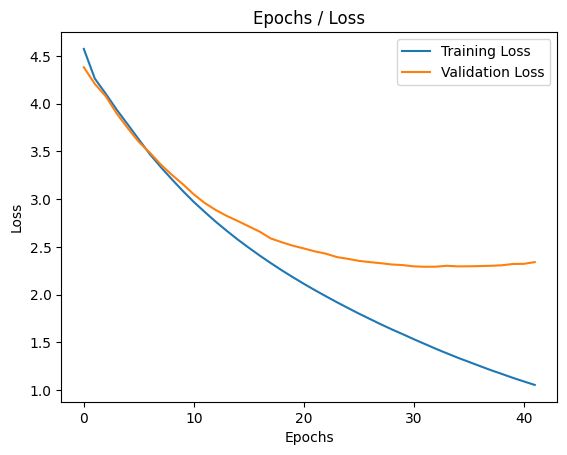

```python
#############################################
# SOLUCIÓ                                   #
#############################################

# ...
```

#### 1.1.2.2 Carregar des de checkpoint y continuar entrenament

Executar aquest apartado 1.1.2.2 únicamente per a:

- **Reiniciar un entrenamient**: només en cas de que s'hagi de reiniciar l'entrenament des de l'última 'epoch' que va actualizar el model, segons la validació definida en el parámetro `checkpoint`.

o bé

- **Carregar un modelo** prèviament entrenat y es vol recuperar-lo per a realitzar prediccions.

Cal fer:

**Reiniciar l'entrenament**

En cas de cancel·lació anticipada durante l'entrenament, es pot reiniciar l'entrenament des de l'último checkpoint, seguint els següents passos:

1. Repetir les seccions **0. Connexió amb drive** i **1.1.1 Preparació de dades** en cas de que la cancel·lació va provocar també finalitzar el runtime o la GPU RAM estava totalment exhaurida.
2. Executar les cel·les amb les funcions *load_ta_model()* i *resume_training()* d'aquesta mateixa secció 1.1.2.2.
3. Executar la tercera cel·la d'aquesta secció 1.1.2.2: *Load model and resume training when needed*, on s'especifica com carregar i reiniciar l'entrenament i que invoca a les funcions anteriors.

**Carregar un model prèviament entrenat**

Quan es necessiti carregar un model ja entrenat per al seu ús posterior en una altra sessió de treball:

1. Repetir, si s'inicia la sessió, les seccions **0. Connexió amb drive** y **1.1.1 Preparació de dades**
2. Executar la cel·la amb la funció *load_ta_model()* d'aquesta secció 1.1.2.2.
3. Executar la quarta cel·la d'aquesta secció 1.1.2.2: *Load model*, on s'especifica com carregar el model, invocant la función anterior. Si s'han entrenat diferents models, recordar modificar la variable *model_path* assignant el nom del model a recuperar.

```python
def load_ta_model (model_path):
    """Loads a pre-trained model from a specified file path.

    This function attempts to load a saved model, including its architecture,
    weights, and optimizer state, from the given file path.

    Args:
        model_path (str): The file path where the saved model file is located.

    Returns:
        object: The loaded 'Keras model' object if the file exists and the underlying
                `load_model` function executes successfully.
        None: If the file specified by `model_path` does not exist or if the
              `load_model` function raises an exception during loading.
    """
    print(f"Loading model from: {model_path}")
    mt_model = None
    if not os.path.exists(model_path):
        print(f"ERROR: Model file not found at {model_path}.")
    else:
        try:
            # Load the model, includes architecture, weigths and optimizer state
            mt_model = load_model(model_path)
            print("Model loaded successfully!")
        except Exception as e:
            print(f"ERROR: Unable to load model from {model_path}. Error: {e}")
    return mt_model
```

```python
def resume_training (model_path, mt_model, trainX, trainY, batch_size, last_epoch_completed, epochs):
    """Resumes training a given model starting from a specific epoch count.

    This function continues the training process for the provided `mt_model` using its `fit` method.
    It utilizes the `initial_epoch` argument of `fit` to specify where the epoch counting should begin.

    A ModelCheckpoint callback is configured to monitor the validation loss and save only
    the best performing model found during this resumed training phase to `model_path`.

    Args:
        model_path (str): The file path where the best model checkpoint will be saved.
        mt_model (object): The pre-loaded machine learning keras model instance to continue training.
        trainX (np.ndarray): The input features for training.
        trainY (np.ndarray): The target labels for training.
        batch_size (int): The number of samples per batch during training updates.
        last_epoch_completed (int): The epoch index at which to START this training session.
        epochs (int): The total number of epochs the model should be trained.

    Returns:
        None: This function does not explicitly return any value. The training modifies the `mt_model` in place.
    """


    print(f"Resuming training from epoch {last_epoch_completed} up to {epochs} epochs...")

    checkpoint = ModelCheckpoint(
        model_path,
        monitor='val_loss',
        verbose=1,
        save_best_only=True
        mode='min'
    )

    early_stop = EarlyStopping(
        monitor='val_loss',
        patience=patience,
        restore_best_weights=True,
        verbose=1,
        start_from_epoch=30
    )

    history = mt_model.fit(
        trainX,
        trainY,
        epochs=epochs,
        initial_epoch=last_epoch_completed,
        batch_size=batch_size,
        validation_split = 0.2,
        callbacks=[checkpoint, early_stop],
        verbose=1
    )

    print("Training resumed and completed")
```

```python
# Secció 'Load model and resume training when needed'
#
# PER A REENTRENAR:
#
# 1. Canviar load_and_resume a True
# 2. Indicar a last_epoch_completed l'última 'epoch' que va actualitzar i millorar el model (per a això veure sortida de la cel·la d'entrenament anterior)
# 3. Executar aquesta cel·la
#
# Per seguretat, restaurar load_and_resume a False
#

load_and_resume = False    # Change to 'True' when needed

if load_and_resume:
    model_path = 'TA/model/model_ta_en_de.keras'
    mt_model = load_ta_model(model_path)

    # ========================
    last_epoch_completed = 7    # Check the last epoch completed during training and modify here
    # ========================

    # 'resume_training' function modifies the model in-place.
    resume_training(model_path,
                    mt_model,
                    trainX,
                    trainY,
                    batch_size,
                    last_epoch_completed,
                    epochs)
```

```python
# Secció Load model
#
# PER A CARREGAR UN MODEL JA ENTRENAT:
#
# 1. Canviar only_load_model a True
# 2. Revisar, i en el seu cas modificar, el 'model_path' del model a recuperar
# 2. Executar aquesta cel·la
#
# Per seguretat, restaurar only_load_model a False
#

only_load_model = False     # Change when necessary


if only_load_model:
    model_path = 'TA/model/model_ta_en_de.keras'
    mt_model = load_ta_model(model_path)
```

[output not shown]

### 1.1.3 Predir

**a. Generar prediccions.**

Un cop entrenat el model, aplicar el mètode *predict()* a l'arxiu de test per a obtenir les prediccions.

**Important:** Si degut a les limitacions d'infraestructura, no es pot realitzar la predicció amb la totalitat de l'arxiu de testX, utilitzar-ne un subconjunt.

*Sortides Esperades*:

- shape de les raw predictions (raw_preds) i
- shape predictions (preds)
- print de les dues primeres prediccions

```python
#############################################
# SOLUCIÓ                                  #
#############################################

# OPTIONAL. Execute this only if running out of memory
test_short = True # Cambiar a True para elegir las primeras 100 filas.
if test_short:
    testX_to_pred = testX[:100]
else:
    testX_to_pred = testX


# ...

print(f"Raw predictions shape: {raw_preds.shape}");
print(f"Predictions shape: {preds.shape}");
print(f"First predicions: {preds[:2]}")
```

```
2/2 ━━━━━━━━━━━━━━━━━━━━ 1s 337ms/step
Raw predictions shape: (100, 8, 14587)
Predictions shape: (100, 8)
First predicions: [[  2 357  24   0   0   0   0   0]
 [ 39   6  43  89  89  89  89   0]]
```

**b. Visualització de resultats.**

Visualitzem els resultats de les prediccions amb els valors esperats.

*Resultat esperat:* Prediccions traduïdes de les primeres 10 entrades del conjunt de prova. Aquestes prediccions es mostraran amb els textos esperats a efectes de comprovar la bondat de la predicció.

```python
#############################################
# SOLUCIÓ                                #
#############################################

# ...

pred_df = pd.DataFrame({'actual' : test[:,1][:10], 'predicted' : preds_text})

pred_df
```

|  | actual | predicted |
| --- | --- | --- |
| 0 | ik voel me rot | ik voel me |
| 1 | wil je rode of witte wijn bij de maaltijd | wil je nog of |
| 2 | je ziet er voldaan uit | je ziet er gelukkig uit |
| 3 | vind je dat goed | is dat al onder |
| 4 | je kan niet op dat eiland wonen | je kan niet in niet |
| 5 | het was keihard | het was zo |
| 6 | ik ging tegen mijn zin akkoord | ik ben me het eens |
| 7 | tom bakte brood | tom heeft brood |
| 8 | ik denk niet dat tom me ooit zal vergeven dat ... | ik denk niet dat tom ooit zal |
| 9 | het uitzicht is goed vanaf hier | het hier komt het |

### 1.1.4 Experimentació amb diferents resultats

En aquest apartat podríem analitzar com afecta a la qualitat de la traducció la variació de diferents paràmetres del model com ara:

- longitud d'embeddings (*embedding_vec_length*),
- longitud de seqüència (*max_text_length*),
- número de units (*units*),
- batch size,
- epochs,
- ...

No obstant això, degut a que no sempre ens trobarem amb GPUs lliures, aquí ens limitarem a experimentar amb els paràmetres:

- *embedding_vec_length* i
- *max_text_length*.

**Important:** durant les execucions, depenent del model i del consum de memòria actual, la predicció pot cancel·lar si s'exhaureix la memòria disponible. En cas de cancel·lació, recarregar el model des de local (veue apartat 1.1.2.2) i predir només un subconjunt de l'arxiu de test (tot i que en aquest cas no seran vàlides les magnituds de medició de qualitat del sistema)

A més, suggerim que després de cada entrenament es realitzi una còpia del model entrenat i s'emmagatzemi en local (*'model/...'*) per a, en cas de cancel·lació, no haver de realitzar de nou l'entrenament, associant al nom de la còpia els paràmetres amb els que ha estat entrenat.

**a. Experimentar amb el valor de longitud de embedding** (*embedding_vec_length*)

Analitzar com un increment en la mida dels vectors de embedding afecta al rendiment d'un model de traducció automàtica de **l'idioma origen** a **l'idioma destí**.

**Resultat esperat:** S'imprimirà el resultat que mostri el rendiment del model creat per a diferents mides d'embeddings (inicialment s'ha treballat amb 200, també es podria experimentar amb valors com ara 50 i 300). Cada resultat constarà de la mida de l'embedding seguit d'un **score** que n'indiqui l'efectivitat del model calculat amb *model.evaluate()*.

```python
#############################################
# SOLUCIÓ, embedding_vec_length = 50       #
#############################################

# ...

plt.plot(history.history['loss'], label='Training Loss')
plt.plot(history.history['val_loss'], label='Validation Loss')
plt.title('Epochs / Loss')
plt.xlabel('Epochs')
plt.ylabel('Loss')
plt.legend()
plt.show()
```

[output not shown]

**b. Exercici opcional: Experimentar amb el valor de longitud de seqüència** (*max_text_length*)

Analitzar com un increment/reducció de la longitud de seqüència impacta en la qualitat del model de traducció.

**Resultat esperat:** S'imprimirà el resultat que mostri el rendiment del model per a una longitud de seqüència superior o inferior a l'establert (per exemple, si es va inicialitzar el model preliminar amb el valor de 8, aquí es podria provar amb 4 i 12). El resultat constarà del valor de la longitud, i del score que indica l'efectivitat del model calculat amb *model.evaluate()*

```python
#############################################
# SOLUCIÓ, max_text_length = 4              #
#############################################

# ...

# WARNING,  WARNING
# Make sure to rebuild trainX and trainY according to the new sequence length

history = mt_model.fit(
    trainX,
    trainY,
    epochs=epochs,
    batch_size=batch_size,
    validation_split = 0.2,
    callbacks=[checkpoint, early_stop],
    verbose=1
)

#...

plt.plot(history.history['loss'], label='Training Loss')
plt.plot(history.history['val_loss'], label='Validation Loss')
plt.title('Epochs / Loss')
plt.xlabel('Epochs')
plt.ylabel('Loss')
plt.legend()
plt.show()
```

[output not shown]

D'acord amb els resultats obtinguts en aquest exercici, en el document d'Anàlisi s'espera es comentin les diferències observades.

## 1.2 TA amb Embeddings preentrenats

En aquest apartat repetirem l'exercici anterior carregant a la capa d'embedding els pesos d'un model `GloVe` entrenat per a l'anglès.

Aquest apartat 1.2 pot executar-se en diferents sessions de treball; no depèn de les seccions anteriors a excepció de:

- Executar l'apartat *0. Connexió amb Drive* (o les cel·les que s'hagin definit per a altres entorns no Colab).
- Executar l'apartat *Imports*
- Executar l'apartat *1.1.0 Hiperparàmetres*. **IMPORTANT** El paràmetre *embedding_vec_length* ha de coincidir amb la dimensió del vector de GloVe (inicialment 300)
- Executar la cel·la de preparació de dades (secció 1.1.1)
- Només quan sigui necessari, executar les cel·les de l'apartat *1.1.2.2 Carregar des de checkpoint i continuar l'entrenament* i invocar las corresponents funcions amb el path del model emmagatzemat en local corresponent a aquest apartat sobre Embeddings preentrenats.

### 1.2.1 Càrrega de `GloVe`

**a. Començarem carregant el model `Glove`per a l'anglès.**

Podeu utilitzar [`'glove.42B.300d.txt'`](https://www.kaggle.com/datasets/yutanakamura/glove42b300dtxt).

*Sortida esperada:* mida de l'objecte carregat, utilitzar *len()*.

```python
#############################################
# SOLUCIÓ                                  #
#############################################

# ...

print(f"Number of words: {len(embeddings_index)}")

# ...

print(f"Embedding vector length GloVe: {embedding_vec_length_glove}")
```

```
Attempting to open glove file: /content/drive/MyDrive/UOC/20251_Mineria_de_Textos/PRA2/TA/glove.42B.300d.txt
Successfully opened glove file: glove.42B.300d.txt. Embeddings index dictionary created. Key: word. Value: Embedding
Number of words: 1917494
word: ',', first embedding values: [ 0.18378  -0.12123  -0.11987   0.015227 -0.19121  -0.066074 -2.9876
  0.80795   0.067338 -0.13184  -0.5274    0.44521   0.12982  -0.21823
 -0.4508   -0.22478  -0.30766  -0.11137  -0.162    -0.21294 ]...
word: 'the', first embedding values: [-0.20838   -0.14932   -0.017528  -0.028432  -0.060104  -0.2646
 -4.1445     0.62932    0.33672   -0.43395    0.39899   -0.19573
  0.13977   -0.021519   0.37823   -0.5525    -0.1123    -0.0081443
  0.29059    0.066817 ]...
word: '.', first embedding values: [ 1.0876e-01  2.2438e-03  2.2213e-01 -1.2102e-01 -4.8959e-02  1.8135e-02
 -3.8174e+00 -3.2631e-02 -6.2594e-01 -5.1898e-01 -3.5893e-01  7.8871e-01
 -2.9777e-01  5.1860e-03 -4.1814e-01  2.4691e-01 -1.3584e-01 -1.9046e-01
 -2.9987e-01 -6.3696e-01]...
word: 'and', first embedding values: [-0.09611 -0.25788 -0.3586  -0.32887  0.5795  -0.51774 -4.1582  -0.11371
 -0.10848 -0.48885  0.19931 -0.1054  -0.43825 -0.34483 -0.45052 -0.34864
 -0.458   -0.81554  0.22006  0.20254]...
word: 'to', first embedding values: [-0.24837  -0.45461   0.039227 -0.28422  -0.031852  0.26355  -4.6323
  0.01389  -0.53928  -0.084454  0.061556 -0.41552  -0.14599  -0.59321
 -0.028738 -0.034991 -0.29698  -0.07985   0.27312   0.2204  ]...
word: 'of', first embedding values: [-0.036429  -0.28592    0.063387  -0.60122   -0.015309   0.073243
 -3.8547     0.52809   -0.077859  -0.40756    0.44713    0.0056261
 -0.38887   -0.0092043  0.26061   -0.45271   -0.50423   -0.38904
 -0.30564    0.42003  ]...
word: 'a', first embedding values: [-0.035835  0.77844  -0.51806   0.080682 -0.13173  -0.28606  -4.2485
  0.81827   0.24034  -0.69057   0.21556  -0.12434  -0.54229  -0.15138
 -0.13591  -0.5348    0.34595  -0.22926  -0.013789  0.047816]...
word: 'in', first embedding values: [ 6.8507e-02 -2.3344e-02  2.8271e-01 -4.0215e-01  7.7815e-02 -2.7003e-02
 -3.7645e+00  4.1708e-01  5.8373e-02 -6.7997e-02  3.2045e-01  9.3317e-02
  3.5446e-01  2.4415e-01 -2.2822e-01  2.1088e-01  9.2499e-02 -7.6600e-02
 -3.0272e-03  6.5657e-01]...
word: '"', first embedding values: [-0.048032 -0.6914   -0.21957   0.089568  0.28472  -1.0531   -3.4121
  0.02696  -0.20037  -0.53091   0.97056  -0.034644 -0.10033  -0.2071
 -0.42032   0.16462   0.059077 -0.61837   0.23765   0.22807 ]...
word: 'is', first embedding values: [ 0.11396   0.34503  -0.055064 -0.20192   0.20848  -0.09699  -4.0236
  0.95046  -0.060803 -0.8326    0.39128   0.080882  0.19049  -0.043595
 -0.39001  -0.34955   0.11262  -0.14287  -0.032761  0.067908]...
Embedding vector length GloVe: 300
```

### 1.2.2 Definició del model

**a. Construir la matriu d'embeddings.**

A continuació, hem de construir la matriu d'embeddings.

Per a no carregar tot el vocabulari del model, filtrarem només aquelles entrades presents en el vocabulari del tokenitzador que utilitzarem.

A més, inclourem a la matriu de vectors els índexs de les entrades, paraules, que no constin en el model `glove` carregat. Aquests vectors se solen inicialitzar amb zeros o amb el resultat d'una distribució N (0, 1).

**Sortida esperada:**:

- Dimensió de la matriu d'embeddings
- Nombre de paraules que consten a Glove i les que no hi consten.
- 10 Primeres paraules que consten a Glove y 10 primeres que no hi consten.
- Imprimir els 3 primers elements de la matriu d'embeddings.

```python
#############################################
# SOLUCIÓ                                   #
#############################################

# ...
```

[output not shown]

[output cut: 174 more lines]

```
  -3.03959996e-01  1.52899995e-01 -1.06930006e+00  4.96870011e-01
   1.40400007e-01  2.64030010e-01 -3.05940002e-01  1.56250000e-01
  -4.54169996e-02  4.02660012e-01  6.90060034e-02  7.71149993e-02
   3.22780013e-02  1.01739997e-02  4.68349993e-01 -7.59050027e-02
   4.58149999e-01 -8.94780010e-02  3.40560004e-02  7.58659989e-02
  -5.17970026e-01 -4.43019986e-01  2.68510003e-02 -1.30009994e-01
  -3.56630012e-02 -3.55560005e-01  1.96739994e-02 -1.00149997e-01
   7.70829991e-02 -4.64690000e-01 -6.01020008e-02 -3.11729997e-01
  -2.48429999e-01 -3.08869988e-01  5.18109985e-02  9.81810018e-02
   3.56909990e-01  2.40600005e-01  3.66219997e-01  4.68490012e-02
   1.11070001e+00 -2.86320001e-01  4.90630001e-01  4.04940009e-01
  -4.10219980e-03  1.99970007e-01 -2.47099996e-02  2.17429996e-01
  -1.04440004e-01  1.72419995e-01 -1.52219996e-01 -1.01190001e-01
  -2.05080003e-01 -3.75180006e-01  2.16230005e-01  2.64670014e-01
  -8.16560015e-02  1.00800000e-01  1.06799997e-01  8.90650004e-02]]
```

**b. Inicialitzar la capa d'embeddings.**

Per a inicialitzar una capa d'embeddings amb pesos predefinits s'utilitza l'argument `weights`.

A més, valorar si el paràmetre `trainable`es considera 'True' o 'False' en funció de si existeixen paraules del vocabulari de l'idioma origen que no existeixen a GloVe. Realitzar proves amb tos dos valors.

*Sortida Esperada*:

Dimensions de la capa de Embedding

```python
# WARNING. Check Hyperparameter section
# embedding_vec_length should be the same as the Glove embedding vec length

# ...
```

```
Pre-training Embedding Layer defined
Actual Matrix Shape: (10102, 300)
```

**c. Definició del nou model considerant els pesos del model preentrenat.**

Implementa i entrena de nou un model de traducció automàtica de **l'idioma origen** a **l'idioma destí**; aquest cop carregant els pesos de la capa embedding a partir del model `Glove` preentrenat en anglès i disponible a `glove.42B.300d.txt`.

*Solució esperada*: 'summary' de la definició del model

```python
#############################################
# SOLUCIÓ                                   #
#############################################

# ...

mt_model.summary()
```

```
Model: "sequential_1"
```

```
┏━━━━━━━━━━━━━━━━━━━━━━━━━━━━━━━━━┳━━━━━━━━━━━━━━━━━━━━━━━━┳━━━━━━━━━━━━━━━┓
┃ Layer (type)                    ┃ Output Shape           ┃       Param # ┃
┡━━━━━━━━━━━━━━━━━━━━━━━━━━━━━━━━━╇━━━━━━━━━━━━━━━━━━━━━━━━╇━━━━━━━━━━━━━━━┩
│ embedding_3 (Embedding)         │ (None, 8, 300)         │     3,030,600 │
├─────────────────────────────────┼────────────────────────┼───────────────┤
│ lstm_2 (LSTM)                   │ (None, 512)            │     1,665,024 │
├─────────────────────────────────┼────────────────────────┼───────────────┤
│ repeat_vector_1 (RepeatVector)  │ (None, 8, 512)         │             0 │
├─────────────────────────────────┼────────────────────────┼───────────────┤
│ lstm_3 (LSTM)                   │ (None, 8, 512)         │     2,099,200 │
├─────────────────────────────────┼────────────────────────┼───────────────┤
│ dense_1 (Dense)                 │ (None, 8, 14587)       │     7,483,131 │
└─────────────────────────────────┴────────────────────────┴───────────────┘
```

```
 Total params: 14,277,955 (54.47 MB)
```

```
 Trainable params: 14,277,955 (54.47 MB)
```

```
 Non-trainable params: 0 (0.00 B)
```

**d. Compilem el model**

*Solució esperada*: 'summary' de la definició del model

```python
#############################################
# SOLUCIÓ                                 #
#############################################


# ...
```

```
Model: "sequential_1"
```

```
┏━━━━━━━━━━━━━━━━━━━━━━━━━━━━━━━━━┳━━━━━━━━━━━━━━━━━━━━━━━━┳━━━━━━━━━━━━━━━┓
┃ Layer (type)                    ┃ Output Shape           ┃       Param # ┃
┡━━━━━━━━━━━━━━━━━━━━━━━━━━━━━━━━━╇━━━━━━━━━━━━━━━━━━━━━━━━╇━━━━━━━━━━━━━━━┩
│ embedding_3 (Embedding)         │ (None, 8, 300)         │     3,030,600 │
├─────────────────────────────────┼────────────────────────┼───────────────┤
│ lstm_2 (LSTM)                   │ (None, 512)            │     1,665,024 │
├─────────────────────────────────┼────────────────────────┼───────────────┤
│ repeat_vector_1 (RepeatVector)  │ (None, 8, 512)         │             0 │
├─────────────────────────────────┼────────────────────────┼───────────────┤
│ lstm_3 (LSTM)                   │ (None, 8, 512)         │     2,099,200 │
├─────────────────────────────────┼────────────────────────┼───────────────┤
│ dense_1 (Dense)                 │ (None, 8, 14587)       │     7,483,131 │
└─────────────────────────────────┴────────────────────────┴───────────────┘
```

```
 Total params: 14,277,955 (54.47 MB)
```

```
 Trainable params: 14,277,955 (54.47 MB)
```

```
 Non-trainable params: 0 (0.00 B)
```

### 1.2.3 Entrenament del model

#### 1.2.3.1 Entrenar i guardar el model.

*Sortida Esperada*

- Path de la carpeta on s'ubicarà el best model
- Plot validation_loss / training_loss

```
736/736 ━━━━━━━━━━━━━━━━━━━━ 0s 80ms/step - accuracy: 0.8956 - loss: 0.3660
Epoch 1: val_loss improved from inf to 2.23175, saving model to TA/model/model_ta_en_de-g.keras
736/736 ━━━━━━━━━━━━━━━━━━━━ 66s 90ms/step - accuracy: 0.8956 - loss: 0.3660 - val_accuracy: 0.6510 - val_loss: 2.2318
736/736 ━━━━━━━━━━━━━━━━━━━━ 0s 80ms/step - accuracy: 0.8989 - loss: 0.3539
Epoch 2: val_loss did not improve from 2.23175
736/736 ━━━━━━━━━━━━━━━━━━━━ 66s 89ms/step - accuracy: 0.8989 - loss: 0.3540 - val_accuracy: 0.6506 - val_loss: 2.2439
736/736 ━━━━━━━━━━━━━━━━━━━━ 0s 80ms/step - accuracy: 0.9018 - loss: 0.3411
Epoch 3: val_loss did not improve from 2.23175
736/736 ━━━━━━━━━━━━━━━━━━━━ 65s 89ms/step - accuracy: 0.9018 - loss: 0.3411 - val_accuracy: 0.6526 - val_loss: 2.2638
736/736 ━━━━━━━━━━━━━━━━━━━━ 0s 80ms/step - accuracy: 0.9051 - loss: 0.3288
Epoch 4: val_loss did not improve from 2.23175
736/736 ━━━━━━━━━━━━━━━━━━━━ 66s 90ms/step - accuracy: 0.9051 - loss: 0.3288 - val_accuracy: 0.6517 - val_loss: 2.2783
736/736 ━━━━━━━━━━━━━━━━━━━━ 0s 80ms/step - accuracy: 0.9074 - loss: 0.3196
Epoch 5: val_loss did not improve from 2.23175
736/736 ━━━━━━━━━━━━━━━━━━━━ 66s 89ms/step - accuracy: 0.9074 - loss: 0.3196 - val_accuracy: 0.6526 - val_loss: 2.2870
736/736 ━━━━━━━━━━━━━━━━━━━━ 0s 80ms/step - accuracy: 0.9095 - loss: 0.3087
Epoch 6: val_loss did not improve from 2.23175
736/736 ━━━━━━━━━━━━━━━━━━━━ 66s 89ms/step - accuracy: 0.9095 - loss: 0.3088 - val_accuracy: 0.6503 - val_loss: 2.2992
736/736 ━━━━━━━━━━━━━━━━━━━━ 0s 81ms/step - accuracy: 0.9128 - loss: 0.2976
Epoch 7: val_loss did not improve from 2.23175
736/736 ━━━━━━━━━━━━━━━━━━━━ 67s 90ms/step - accuracy: 0.9128 - loss: 0.2976 - val_accuracy: 0.6506 - val_loss: 2.3172
736/736 ━━━━━━━━━━━━━━━━━━━━ 0s 80ms/step - accuracy: 0.9151 - loss: 0.2878
Epoch 8: val_loss did not improve from 2.23175
736/736 ━━━━━━━━━━━━━━━━━━━━ 81s 89ms/step - accuracy: 0.9151 - loss: 0.2879 - val_accuracy: 0.6489 - val_loss: 2.3259
736/736 ━━━━━━━━━━━━━━━━━━━━ 0s 80ms/step - accuracy: 0.9160 - loss: 0.2832
Epoch 9: val_loss did not improve from 2.23175
736/736 ━━━━━━━━━━━━━━━━━━━━ 66s 89ms/step - accuracy: 0.9160 - loss: 0.2832 - val_accuracy: 0.6500 - val_loss: 2.3412
736/736 ━━━━━━━━━━━━━━━━━━━━ 0s 80ms/step - accuracy: 0.9187 - loss: 0.2729
Epoch 10: val_loss did not improve from 2.23175
736/736 ━━━━━━━━━━━━━━━━━━━━ 66s 90ms/step - accuracy: 0.9187 - loss: 0.2729 - val_accuracy: 0.6496 - val_loss: 2.3456
736/736 ━━━━━━━━━━━━━━━━━━━━ 0s 81ms/step - accuracy: 0.9213 - loss: 0.2639
Epoch 11: val_loss did not improve from 2.23175
736/736 ━━━━━━━━━━━━━━━━━━━━ 66s 90ms/step - accuracy: 0.9213 - loss: 0.2639 - val_accuracy: 0.6537 - val_loss: 2.3686
736/736 ━━━━━━━━━━━━━━━━━━━━ 0s 80ms/step - accuracy: 0.9221 - loss: 0.2589
Epoch 12: val_loss did not improve from 2.23175
736/736 ━━━━━━━━━━━━━━━━━━━━ 66s 89ms/step - accuracy: 0.9221 - loss: 0.2589 - val_accuracy: 0.6533 - val_loss: 2.3845
736/736 ━━━━━━━━━━━━━━━━━━━━ 0s 80ms/step - accuracy: 0.9229 - loss: 0.2554
Epoch 13: val_loss did not improve from 2.23175
736/736 ━━━━━━━━━━━━━━━━━━━━ 66s 90ms/step - accuracy: 0.9229 - loss: 0.2554 - val_accuracy: 0.6528 - val_loss: 2.3943
736/736 ━━━━━━━━━━━━━━━━━━━━ 0s 81ms/step - accuracy: 0.9247 - loss: 0.2487
```

[output cut: 72 more lines]

```
Epoch 38: val_loss did not improve from 2.23175
736/736 ━━━━━━━━━━━━━━━━━━━━ 67s 91ms/step - accuracy: 0.9432 - loss: 0.1734 - val_accuracy: 0.6501 - val_loss: 2.5900
736/736 ━━━━━━━━━━━━━━━━━━━━ 0s 81ms/step - accuracy: 0.9438 - loss: 0.1702
Epoch 39: val_loss did not improve from 2.23175
736/736 ━━━━━━━━━━━━━━━━━━━━ 67s 91ms/step - accuracy: 0.9438 - loss: 0.1703 - val_accuracy: 0.6516 - val_loss: 2.6046
736/736 ━━━━━━━━━━━━━━━━━━━━ 0s 81ms/step - accuracy: 0.9441 - loss: 0.1681
Epoch 40: val_loss did not improve from 2.23175
736/736 ━━━━━━━━━━━━━━━━━━━━ 67s 91ms/step - accuracy: 0.9441 - loss: 0.1682 - val_accuracy: 0.6537 - val_loss: 2.6088
736/736 ━━━━━━━━━━━━━━━━━━━━ 0s 80ms/step - accuracy: 0.9431 - loss: 0.1690
Epoch 41: val_loss did not improve from 2.23175
736/736 ━━━━━━━━━━━━━━━━━━━━ 66s 90ms/step - accuracy: 0.9431 - loss: 0.1690 - val_accuracy: 0.6539 - val_loss: 2.6059
Epoch 41: early stopping
Restoring model weights from the end of the best epoch: 31.
Training complete
Model saved in: TA/model/model_ta_en_de-g.keras
```

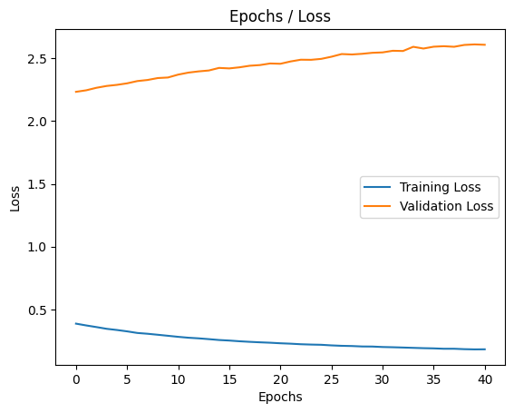

```python
#############################################
# SOLUCIÓ                                   #
#############################################

# ...

print("Training complete")
print(f"Model saved in: {model_path}")

plt.plot(history.history['loss'], label='Training Loss')
plt.plot(history.history['val_loss'], label='Validation Loss')
plt.title('Epochs / Loss')
plt.xlabel('Epochs')
plt.ylabel('Loss')
plt.legend()
plt.show()
```

#### 1.2.3.2 Carregar des de checkpoint y continuar entrenament (pas opcional)

Executar aquest apartat únicamente per a:

- **Reiniciar un entrenamient**: només en cas de que s'hagi de reiniciar l'entrenament des de l'última 'epoch' que va actualizar el model, segons la validació definida en el paràmetre `checkpoint`.

o bé

- **Carregar un model** prèviament entrenat y es vol recuperar-lo per a realitzar prediccions.

Cal fer:

**Reiniciar l'entrenament**

En cas de cancel·lació anticipada durante l'entrenament, es pot reiniciar l'entrenament des de l'último checkpoint, seguint els següents passos:

**Carregar un model prèviament entrenat**

Quan es necessiti carregar un model ja entrenat per al seu ús posterior en una altra sessió de treball:

1. Repetir, si s'inicia la sessió, les seccions **0. Connexió amb drive** y **1.1.1 Preparació de dades**.
2. Executar la cel·la amb la funció *load_ta_model()* de la secció 1.1.2.2.
3. Ejecutar la segona cel·la d'aquesta secció 1.2.3.2: *Load model*, on s'especifica com carregar el model, invocant la función anterior. Si s'han entrenat diferents models, recordar modificar la variable *model_path* assignant el nom del model a recuperar.

```python
# load and resume

load_and_resume = False    # Change to 'True' when needed

from keras.models import load_model

if load_and_resume:
    model_path = 'TA/model/model_ta_en_de-g.keras'
    mt_model = load_ta_model(model_path)

    # ========================
    last_epoch_completed = 24    # Check the last epoch completed during training and modify here
    epochs = 100
    # ========================
    batch_size = 64
    # 'resume_training' function modifies the model in-place.
    resume_training(model_path,
                    mt_model,
                    trainX,
                    trainY,
                    batch_size,
                    last_epoch_completed,
                    epochs)
```

```python
# load model

only_load_model = True    # Change when necessary

if only_load_model:
    model_path = 'TA/model/model_ta_en_de-g.keras'
    mt_model = load_ta_model(model_path)
```

### 1.2.4 Generar prediccions

En aquest pas, aplicar el model per a generar les prediccions utilitzant l'arxiu de test.

*Sortides Esperades*:

- shape de les raw predictions (raw_preds) i
- shape predictions (preds)
- print de les dues primeres prediccions
- Prediccions traduïdes de les primeres 10 entrades del conjunt de prova. Aquestes prediccions es mostraran amb els textos esperats a efectes de comprovar la bondat de la predicció.

**Suggeriment:** Si durant l'execució, cancel·la la predicció per exhaurir-se la memòria disponible, recarregar el model des de local (veure apartat 1.2.3.2) i predir només per a un subconjunt de l'arxiu de test (tot i que en aquest cas no seran vàlides les magnituds de medició de qualitat del sistema).

```python
#############################################
# SOLUCIÓ                                 #
#############################################
reducir_test = True      # True when translating only 100 first rows.
if reducir_test:
    testX_to_pred = testX[:100]
else:
    testX_to_pred = testX


# ...
```

```
2/2 ━━━━━━━━━━━━━━━━━━━━ 1s 257ms/step
Raw predictions shape: (100, 8, 14587)
Predictions shape: (100, 8)
First predicions: [[  2 357  24   0   0   0   0   0]
 [ 39   6  89  89  89  89 629   4]]
```

|  | actual | predicted |
| --- | --- | --- |
| 0 | ik voel me rot | ik voel me |
| 1 | wil je rode of witte wijn bij de maaltijd | wil je of rode is |
| 2 | je ziet er voldaan uit | je ziet er gelukkig uit |
| 3 | vind je dat goed | is dat dit goed met jou |
| 4 | je kan niet op dat eiland wonen | je kunt niet bij in leven |
| 5 | het was keihard | het was bikkelhard een |
| 6 | ik ging tegen mijn zin akkoord | ik ging ermee ontslag met |
| 7 | tom bakte brood | tom heeft brood gebakken |
| 8 | ik denk niet dat tom me ooit zal vergeven dat ... | ik denk niet dat tom zal dan |
| 9 | het uitzicht is goed vanaf hier | vanaf hier is het uitzicht mooi |

# 2 Detecció de NER i NEL (3 punts)

En aquesta segona part, ens enfocarem en la detección de entidades anomenades (`NER`).

A més, experimentarem amb 'Named Entity Linking' (`NEL`) per a buscar entitats enllaçades a una base de coneixement (KB), en aquest cas *Wikidata*. Identificarem els enllaços a Wikidata de certes entitats d'un text utilitzant la API de Wikidata.

**Aquest apartat pot executar-se aïlladament**, no depèn de l'apartat anterior, a excepció d'executar l'apartat *0. Connexió amb Drive* (o les cel·les que s'hagin definit per a altres entorns no Colab).

## 2.1 Detecció de `NER`

En aquesta primera subsecció, detectarem entitats anomenades (`NER`), utilitzant tant spaCy com transformers.

### 2.1.1 Detecció d'entitats anomenades (NER) utilitzant spaCy.

Per a detectar NER utilitzarem el model `en_core_web_sm` de spaCy.

**a. Instal·lar llibreries i model de llenguatge a utilitzar.**

```python
!pip install spacy numpy
```

```python
!python -m spacy download en_core_web_sm
```

```
     ━━━━━━━━━━━━━━━━━━━━━━━━━━━━━━━━━━━━━━━━ 12.8/12.8 MB 74.8 MB/s eta 0:00:00
✔ Download and installation successful
You can now load the package via spacy.load('en_core_web_sm')
⚠ Restart to reload dependencies
If you are in a Jupyter or Colab notebook, you may need to restart Python in
order to load all the package's dependencies. You can do this by selecting the
'Restart kernel' or 'Restart runtime' option.
```

**`Important:`**

Si la descàrrega de *'en_core_web_sm'* es realitza des de Google Colab y, després de la descàrrega, es mostra el missatge 'Restart to reload dependencies', executar l'opció de menú 'Runtime>>>Restart session'. A continuació tornar a executar la secció 0 d'aquest notebook i seguir amb el següent apartat 2.1.1.b

**b. Definir funcions per a imprimir els resultats de la detecció.**

```python
def get_tokens_to_print(model, text):
  """Print tokens of the text and its relevant attributes.

    Parameters:
      model (spaCy model): spaCy model used for tokenization
      text (str):  text to transform in a spaCy doc class.

    Returns: ---
  """
  doc = model(text)
  print (f"The text:\n\n{get_text_to_print(text)}\n\nwas converted in a spaCy object: {type(doc)}\n")
  print (f"Token-based analysis. Each token is a spaCy object: {type(doc[0])}\n")

  # We obtain rows to print: headers and content
  rows  = []
  # head_align: List of tuples. Each tuple: heather and its alignment when printing
  head_align  = [('Token', '<'), ('Lemma', '<'), ('Syntactic parent', '<'), ('#Tok', '>'), ('Chr_Start', '>'), ('Chr_End', '>'), ('POS', '<'),
                 ('TAG', '<'), ('TAG meaning:', '<'), ('ENT', '<'), ('DEP', '<'), ('DEP meaning:', '<')]
  head, align = list(zip(*head_align))
  rows.append(head)                           # Header
  rows.append(['='*len(i) for i in head])     # Underline headers
  for tok in doc:
    rows.append([tok.text, tok.lemma_, tok.head.text, str(tok.i), str(tok.idx), str(tok.idx+len(tok)-1), tok.pos_,
                 tok.tag_, str(spacy.explain(tok.tag_))[:20], tok.ent_type_, tok.dep_, str(spacy.explain(tok.dep_))[:20]])

  # Width of each column: the witdh of the longest element
  columns       = zip(*rows)
  column_widths = [max(len(i) for i in col) for col in columns]

  # Print the files with alignment
  for row in rows:
    print(*[f"{row[i]:{align[i]}{column_widths[i]}}  " for i in range(0, len(row))])
```

```python
def get_text_to_print(text):
  """Format given text.

    Parameters:
      text (str): text to print

    Returns:
      str: text formatted in 100 character lines with an initial line numbering the characters
  """
  line_length = 100
  line_poss   = "     1-------10--------20--------30--------40--------50--------60--------70--------80--------90-------100"
  text        = text.replace("\n", " ")     # In order to avoid that the \n character produces a line change.
  text        = text.replace("\r", " ")     # In wikipedia texts we have detected the character '\r' that, if interpreted, may induce some printing problems.
  text_format = "\n".join([ f"{i//line_length:<5}{text[i:i+line_length]}"  for i in range(0, len(text), line_length) ])
  return line_poss + "\n" + text_format + "\n" + line_poss
```

**c. Carregar el model `en_core_web_sm`**

**Resultat esperat**: Codi per a la càrrega del model.

```python
#############################################
# SOLUCIÓ                                   #
#############################################

import spacy

# ...
```

```
Model 'en_core_web_sm' loaded correctly!
```

**d. Convertir un text en objecte `Doc` de spaCy.**

Per a realitzar la detecció d'entitats anomenades, proposar un text en anglès que mencioni a entitats de diferent tipus.

**Sortida Esperada**: Visualitzar els resultats d'analitzar el text proposat a nivell de cada POS.

**Suggeriment:** Per a la visualització es pot utilitzar la funció *get_tokens_to_print()*, prèviament creada, o *displacy.render()* de spaCy.

```python
#############################################
# SOLUCIÓ                                   #
#############################################

# Convertir el text en objeto spaCy 'doc'
text = """\
Plato (born c. 428–423 BC, died 348-347 BC) was an ancient Greek philosopher of \
Classical Athens who is most commonly considered the foundational thinker of the \
Western philosophical tradition."""

# ...
```

```
The text:

     1-------10--------20--------30--------40--------50--------60--------70--------80--------90-------100
0    Plato (born c. 428–423 BC, died 348-347 BC) was an ancient Greek philosopher of Classical Athens who
1     is most commonly considered the foundational thinker of the Western philosophical tradition.
     1-------10--------20--------30--------40--------50--------60--------70--------80--------90-------100

was converted in a spaCy object: <class 'spacy.tokens.doc.Doc'>

Token-based analysis. Each token is a spaCy object: <class 'spacy.tokens.token.Token'>

Token           Lemma           Syntactic parent   #Tok   Chr_Start   Chr_End   POS     TAG     TAG meaning:           ENT        DEP         DEP meaning:
=====           =====           ================   ====   =========   =======   ===     ===     ============           ===        ===         ============
Plato           Plato           died                  0           0         4   PROPN   NNP     noun, proper singula   PERSON     nsubj       nominal subject
(               (               Plato                 1           6         6   PUNCT   -LRB-   left round bracket                punct       punctuation
born            bear            Plato                 2           7        10   VERB    VBN     verb, past participl              acl         clausal modifier of
c.              c.              BC                    3          12        13   PROPN   NNP     noun, proper singula              compound    compound
                                c.                    4          14        14   SPACE   _SP     whitespace                        dep         unclassified depende
428–423         428–423         BC                    5          15        21   NUM     CD      cardinal number        CARDINAL   compound    compound
BC              BC              born                  6          23        24   PROPN   NNP     noun, proper singula   ORG        dobj        direct object
,               ,               Plato                 7          25        25   PUNCT   ,       punctuation mark, co              punct       punctuation
died            die             died                  8          27        30   VERB    VBD     verb, past tense                  ROOT        root
348             348             BC                    9          32        34   NUM     CD      cardinal number        CARDINAL   nummod      numeric modifier
-               -               347                  10          35        35   SYM     SYM     symbol                            punct       punctuation
347             347             348                  11          36        38   NUM     CD      cardinal number                   prep        prepositional modifi
BC              BC              died                 12          40        41   PROPN   NNP     noun, proper singula   ORG        npadvmod    noun phrase as adver
)               )               died                 13          42        42   PUNCT   -RRB-   right round bracket               punct       punctuation
was             be              died                 14          44        46   AUX     VBD     verb, past tense                  conj        conjunct
an              an              philosopher          15          48        49   DET     DT      determiner                        det         determiner
ancient         ancient         philosopher          16          51        57   ADJ     JJ      adjective (English),              amod        adjectival modifier
Greek           greek           philosopher          17          59        63   ADJ     JJ      adjective (English),   NORP       amod        adjectival modifier
philosopher     philosopher     was                  18          65        75   NOUN    NN      noun, singular or ma              attr        attribute
```

[output cut: 17 more lines]

### 2.1.2 Entrenar un nou model de NER amb el corpus escollit de detecció d'entitats.

**a. Convertir el corpus escollit al 'format spaCy'.**

*Suggeriment:* Si el corpus es gran i l'entrenament triga massa, pots generar una versió més reduïda de tots els arxius del corpus escollit (train, dev y test). La reducció es podria fer del 25%.

Recuerda que spaCy conté funcions que permeten convertir formats, com ara *conll*, al format compilat que necessita el mòdul de train de spaCy.

**Sortida esperada:** Codi per a convertir el corpus training (train.txt) i el de validació (valid.txt), del format origen a format spaCy.

```python
#############################################
# SOLUCIÓN                                  #
#############################################

# ...
```

```
ℹ Grouping every 1 sentences into a document.
⚠ To generate better training data, you may want to group sentences
into documents with `-n 10`.
✔ Generated output file (14041 documents):
/content/drive/MyDrive/UOC/20251_Mineria_de_Textos/PRA2/NER/train.spacy
ℹ Grouping every 1 sentences into a document.
⚠ To generate better training data, you may want to group sentences
into documents with `-n 10`.
✔ Generated output file (3250 documents):
/content/drive/MyDrive/UOC/20251_Mineria_de_Textos/PRA2/NER/valid.spacy
```

**b. Descarregar el model `en_core_web_trf`**.

```python
!pip install spacy-curated-transformers
```

[output not shown]

```python
# Force upgrade spacy and install the transformer extension
!pip install -U spacy spacy-transformers thinc
```

[output not shown]

```python
!python -m spacy download en_core_web_trf
```

[output not shown]

```python
!python -m spacy info en_core_web_trf
```

```
=================== Info about pipeline 'en_core_web_trf' ===================

lang                en
name                core_web_trf
version             3.8.0
description         English transformer pipeline (Transformer(name='roberta-base', piece_encoder='byte-bpe', stride=104, type='roberta', width=768, window=144, vocab_size=50265)). Components: transformer, tagger, parser, ner, attribute_ruler, lemmatizer.
author              Explosion
email               contact@explosion.ai
url                 https://explosion.ai
license             MIT
spacy_version       >=3.8.0,<3.9.0
spacy_git_version   5010fcbd3
vectors             {'width': 0, 'vectors': 0, 'keys': 0, 'name': None}
pipeline            ['transformer', 'tagger', 'parser', 'attribute_ruler', 'lemmatizer', 'ner']
components          ['transformer', 'tagger', 'parser', 'attribute_ruler', 'lemmatizer', 'ner']
disabled            []
sources             [{'name': 'OntoNotes 5', 'url': 'https://catalog.ldc.upenn.edu/LDC2013T19', 'license': 'commercial (licensed by Explosion)', 'author': 'Ralph Weischedel, Martha Palmer, Mitchell Marcus, Eduard Hovy, Sameer Pradhan, Lance Ramshaw, Nianwen Xue, Ann Taylor, Jeff Kaufman, Michelle Fr…
requirements        ['spacy-curated-transformers>=0.2.2,<1.0.0']
source              /usr/local/lib/python3.12/dist-packages/en_core_web_trf
download_url        https://github.com/explosion/spacy-models/releases/download/en_core_web_trf-3.8.0/en_core_web_trf-3.8.0-py3-none-any.whl
```

**Important:**

A Google Colab, si després de la descàrrega del model `en_core_web_trf` s'obté el missatge 'Restart to reload dependencies', haurà d'executar-se l'opció de menú 'Runtime>>>Restart session'. A continuació, per a major seguretat, tornar a executar la secció 0 d'aquest notebook.

```python
!python -m spacy validate
```

```
⠙ Loading compatibility table...
✔ Loaded compatibility table

================ Installed pipeline packages (spaCy v3.8.11) ================
ℹ spaCy installation: /usr/local/lib/python3.12/dist-packages/spacy

NAME              SPACY            VERSION
en_core_web_trf   >=3.8.0,<3.9.0   3.8.0   ✔
en_core_web_sm    >=3.8.0,<3.9.0   3.8.0   ✔
```

```python
import spacy
print (f"Spacy version installed: {spacy.__version__}")
```

```
Spacy version installed: 3.8.11
```

**c. Verificar si es pot utilitzar GPU**

Si aquest notebook s'està executant en una GPU, al paràmetre 'gpu-id' se li assignarà 0. Amb aquest canvi, SpaCy utilitzarà la GPU i s'accelerarà el temps d'entrenament.

```python
import torch
if torch.cuda.is_available():
    gpu_id = 0    # Use the first available GPU
    print(f"Using GPU {gpu_id}")
else:
    gpu_id = -1   # Use CPU
    print("Using CPU")
```

```
Using GPU 0
```

**d. Entrenar el model `en_core_web_trf` utilitzant la funció train de spaCy.**

SpaCy realitza l'entrenament del model d'acord amb els paràmetres de l'arxiu de configuración 'config.cfg'. Una descripció de les seccions d'aquesta configuració la pots trobar a: https://spacy.io/usage/training#config; descriu algun canvi que realitzaries si creus que pots millorar l'entrenament.

A més, considera que a l'arxiu 'config.cfg' no es determina un nombre prefixat d'*epochs* (veure sección [training] de 'config.cfg'). El criteri per a finalitzar el determinen els paràmetres *max_steps* (20000) i *patience* (1600). Aquests paràmetres determinen que l'entrenament finalitzarà si es compleix una de les condicions:

- quan s'hagin processat 20000 'batches', o bé
- quan, després de 1600 'batches' processats, no hi ha hagut millora en el model.

**`Interrupció del procés`**

Per restriccions de temps de procés (o per no consumir les *compute unit* de les que disposem a Google Colab), si s'observa que transcorregudes diverses iteracions (per exemple a partir de la tercera) el model ha anat millorant (columna SCORE) y té un valor superior a 0.9, interrompre manualment el procés. El 'best model' fins a aquesta iteració s'emmagatzemarà al path '{my_path_pra2}/NER/output_ner/model-best'. Aquest model és el que s'utilitzarà per a validar o predir

```python
# Training

my_path_pra2 = "/content/drive/MyDrive/UOC/20251_Mineria_de_Textos/PRA2"

!python -m spacy train xxxxxxxx \
    --output xxxxxxxxx \
    --paths.train xxxxxxxxx  \
    --gpu-id $gpu_id \
    --paths.dev xxxxxxxx
```

```
ℹ Saving to output directory:
/content/drive/MyDrive/UOC/20251_Mineria_de_Textos/PRA2/NER/output_ner
ℹ Using GPU: 0

=========================== Initializing pipeline ===========================
[2025-12-04 18:37:16,696] [WARNING] [W112] The model specified to use for initial vectors (en_core_web_trf) has no vectors. This is almost certainly a mistake.
✔ Initialized pipeline

============================= Training pipeline =============================
ℹ Pipeline: ['transformer', 'ner']
ℹ Initial learn rate: 0.0
E    #       LOSS TRANS...  LOSS NER  ENTS_F  ENTS_P  ENTS_R  SCORE
---  ------  -------------  --------  ------  ------  ------  ------
  0       0         453.21    338.67    8.48    7.13   10.47    0.08
  1     200       37612.94  26141.31   53.34   56.62   50.42    0.53
  2     400        4394.57  11914.59   70.38   70.38   70.38    0.70
  3     600        2022.59   5693.74   92.57   92.65   92.49    0.93
  4     800        1225.01   2075.48   95.17   94.96   95.39    0.95
^C
```

**e. Predicció d'un text d'exemple (inferència amb el model entrenat).**

Carregar el millor model entrenat i utilitzar-lo per a predir una frase d'exemple. Recordar que, si el model ja està entrenat y emmagatzemat en una carpeta local, és millor, a l'iniciar una nova sessió, recuperar la millor versió entrenada des de local.

**Resultat esperat:** visualitzar els resultats de la predicció.

```python
#############################################
# SOLUCIÓ                                   #
#############################################

nlp_predict= spacy.load(f"{my_path_pra2}/NER/output_ner/model-best")  #load the best model
text = """\
Next Tuesday, Ana plans to travel to London to start her new job at Google. \
Apple announced earnings of $5 billion from iPhone sales in Cupertino.\
Jules Verne visited the Eiffel Tower while he was in Paris.\
"""


# ...
```

Next Tuesday, Ana PER plans to travel to London LOC to start her new job at Google ORG . Apple ORG announced earnings of $5 billion from iPhone MISC sales in Cupertino LOC . Jules Verne PER visited the Eiffel Tower LOC while he was in Paris LOC .

**f. Avaluar els resultats obtinguts i calcular les mètriques.**

**Sortida Esperada**: Càlcul de les mètriques utilitzant les dades de prova.

**Important:** Abans del càlcul de les mètriques, no oblidar convertir el format de l'arxiu test.txt al 'format spaCy'.

```python
#Usar GPU si és possible:

import torch
if torch.cuda.is_available():
    gpu_id = 0    # Use the first available GPU
    print(f"Using GPU {gpu_id}")
else:
    gpu_id = -1   # Use CPU
    print("Using CPU")
```

```
Using GPU 0
```

```python
#############################################
# SOLUCIÓ                                   #
#############################################

# ...
```

```
ℹ Grouping every 1 sentences into a document.
⚠ To generate better training data, you may want to group sentences
into documents with `-n 10`.
✔ Generated output file (3453 documents):
/content/drive/MyDrive/UOC/20251_Mineria_de_Textos/PRA2/NER/test.spacy
ℹ Using GPU: 0

================================== Results ==================================

TOK     -
NER P   90.77
NER R   91.96
NER F   91.36
SPEED   2925


=============================== NER (per type) ===============================

           P       R       F
LOC    94.84   92.57   93.69
PER    96.38   95.49   95.93
MISC   75.03   83.48   79.03
ORG    88.84   91.51   90.15
```

## 2.2 NEL

En aquesta secció, obtindrem els enllaços a Wikidata relacionats amb les entitats que s'obtenen utilitzant spaCy.

Es desenvoluparà una funció que, donat un text, obtingui automàticament les entitats i les relacionarà amb la corresponent entrada a Wikidata. Per a implementar la solució, podeu usar, por exemple, la llibreria `wikidata.client`, o realitzar sol·licituds directes a la API, utilitzant la llibreria `requests`.

**Important:** El text de l'exemple analitzat en aquest notebook està en català, és per això que es carrega el model `ca_core_news_sm`. Per a analitzar frases en castellà, canviar el model, per ejemplo, usar `es_core_news_sm`. A més, si s'utilitza `requests`, modificar l'idioma a la URL d'accés al EndPoint de WikiData.

**Sortida Esperada**: Llista de les entitats reconegudes en el text, amb la seva respectiva `URI`.

```python
#######################################
### Exemple de text a analitzar       #
#######################################

text = """\
L'escriptor i guionista hongarès László Krasznahorkai \
ha guanyat el Premi Nobel de Literatura 2025.
El recent Nobel, de 71 anys, té la seva primera novel·la "Tango Satànic" (1985) \
traduïda al català per Carles Dachs, editada a Barcelona aquest 2025 per \
Edicions del Cràter, amb seu a Barcelona."""
```

```python
nel_model = "ca_core_news_sm"   # for spanish: "es_core_news_sm"

#!pip install wikidata   #Instalar si es que se va a usar wikidata.client
!python -m spacy download '{nel_model}'
```

```
     ━━━━━━━━━━━━━━━━━━━━━━━━━━━━━━━━━━━━━━━━ 19.6/19.6 MB 58.9 MB/s eta 0:00:00
✔ Download and installation successful
You can now load the package via spacy.load('ca_core_news_sm')
⚠ Restart to reload dependencies
If you are in a Jupyter or Colab notebook, you may need to restart Python in
order to load all the package's dependencies. You can do this by selecting the
'Restart kernel' or 'Restart runtime' option.
```

```python
#############################################
# SOLUCIÓ                                   #
#############################################

import requests
import spacy

from spacy.tokens import Span

# ...
```

```
Entitat reconeguda a spaCy: László Krasznahorkai - Tipus: PER
Identificador Wikidata: Q512062
URL: //www.wikidata.org/wiki/Q512062
Etiquetes/descripcions a Wikidata:
- László Krasznahorkai (label)
- Hungarian novelist and screenwriter (description)

Entitat reconeguda a spaCy: Premi Nobel - Tipus: MISC
Identificador Wikidata: Q7191
URL: //www.wikidata.org/wiki/Q7191
Etiquetes/descripcions a Wikidata:
- Nobel Prize (label)
- set of annual international awards, primarily 5 established in 1895 by Alfred Nobel (description)

Entitat reconeguda a spaCy: Literatura 2025 - Tipus: MISC
Entitat no trobada a Wikidata.

Entitat reconeguda a spaCy: Nobel - Tipus: ORG
Identificador Wikidata: Q7191
URL: //www.wikidata.org/wiki/Q7191
Etiquetes/descripcions a Wikidata:
- Nobel Prize (label)
- set of annual international awards, primarily 5 established in 1895 by Alfred Nobel (description)

Entitat reconeguda a spaCy: Tango Satànic - Tipus: MISC
Identificador Wikidata: Q1315145
URL: //www.wikidata.org/wiki/Q1315145
Etiquetes/descripcions a Wikidata:
- Satantango (label)
- novel by László Krasznahorkai (description)

Entitat reconeguda a spaCy: Carles Dachs - Tipus: PER
Identificador Wikidata: Q56400459
URL: //www.wikidata.org/wiki/Q56400459
Etiquetes/descripcions a Wikidata:
- Carles Dachs Clotet (label)

Entitat reconeguda a spaCy: Barcelona - Tipus: LOC
Identificador Wikidata: Q1492
URL: //www.wikidata.org/wiki/Q1492
Etiquetes/descripcions a Wikidata:
- Barcelona (label)
- city in Catalonia, Spain (description)

Entitat reconeguda a spaCy: Edicions del Cràter - Tipus: ORG
Identificador Wikidata: Q115940215
URL: //www.wikidata.org/wiki/Q115940215
Etiquetes/descripcions a Wikidata:
- Edicions del Cràter (label)

Entitat reconeguda a spaCy: Barcelona - Tipus: LOC
Identificador Wikidata: Q1492
URL: //www.wikidata.org/wiki/Q1492
Etiquetes/descripcions a Wikidata:
- Barcelona (label)
- city in Catalonia, Spain (description)
```

Nota:

- Es podrien comparar resultats, prèvia instal·lació, amb els models:
  - ['ca_core_news_md'](https://spacy.io/models/es#es_core_news_md)
  - ['ca_core_news_lg'](https://spacy.io/models/es#es_core_news_lg)